### Variable cos2

For cos2 values it is similarly possible to change the color and the shape of the variable points as well as the number of top variables, i.e. the ones having the highest cos2 values.

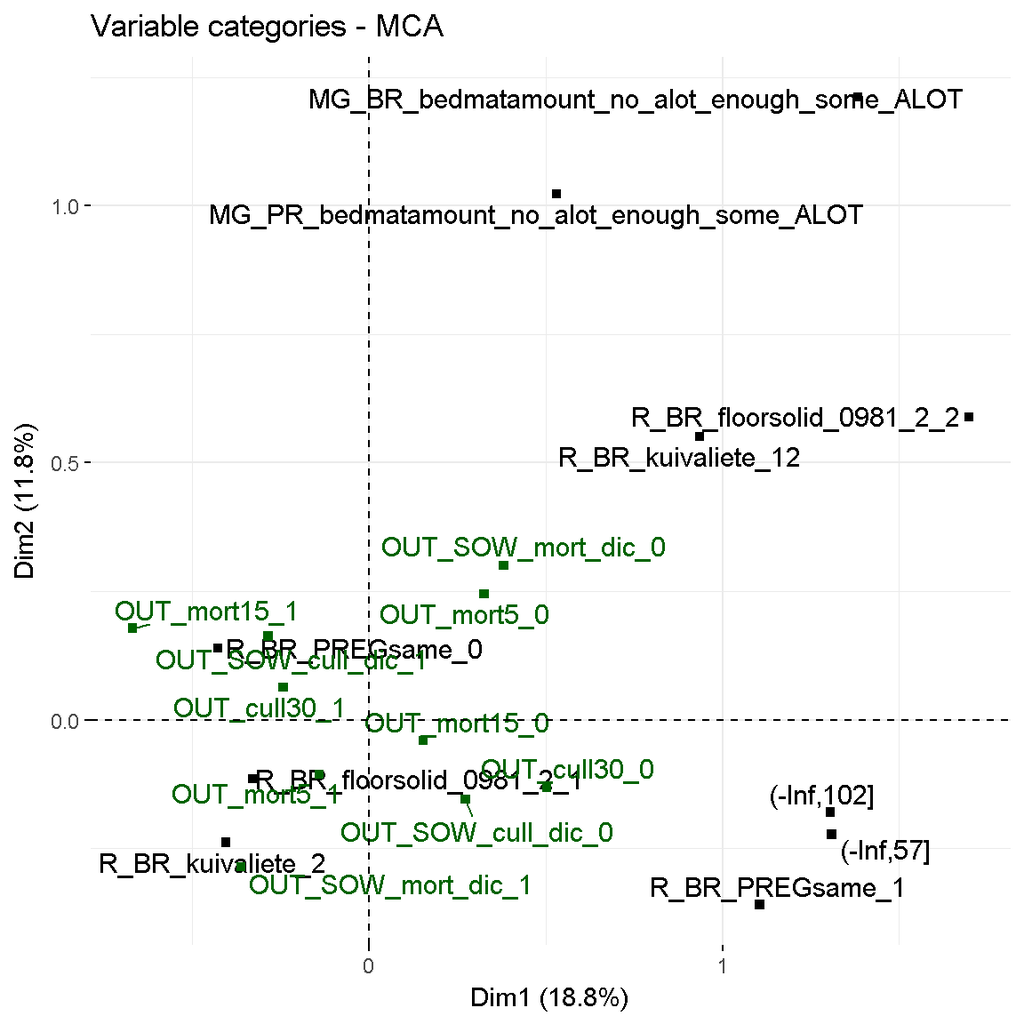

```r
fviz_mca_var(res_mca, col.var="black", shape.var = 15,
             repel = TRUE,select.var = list(cos2 = 10))
```

If a variable category is well represented by two dimensions, the sum of the cos2 is closed to one. For some of the row items, more than 2 dimensions are required to perfectly represent the data. Or it’s transparency of the variable categories according to their cos2 values can be controlled.

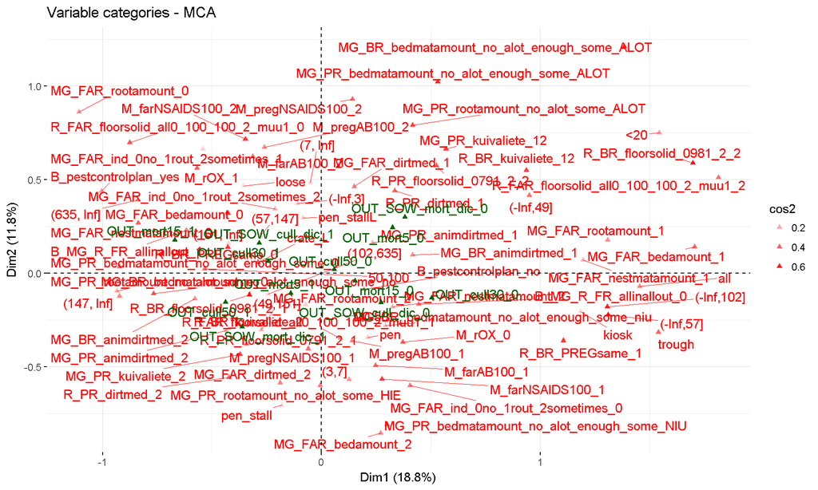

```r
# Change the transparency by cos2 values
fviz_mca_var(res_mca, alpha.var="cos2",
             repel = TRUE,
             ggtheme = theme_minimal(),selectMod="cos2 10")
```

Furthermore, just as with the contributions, variable categories can be gradient-coloured with respect to their cos2 value. Meaning that low, medium and high co2 values have different colours.

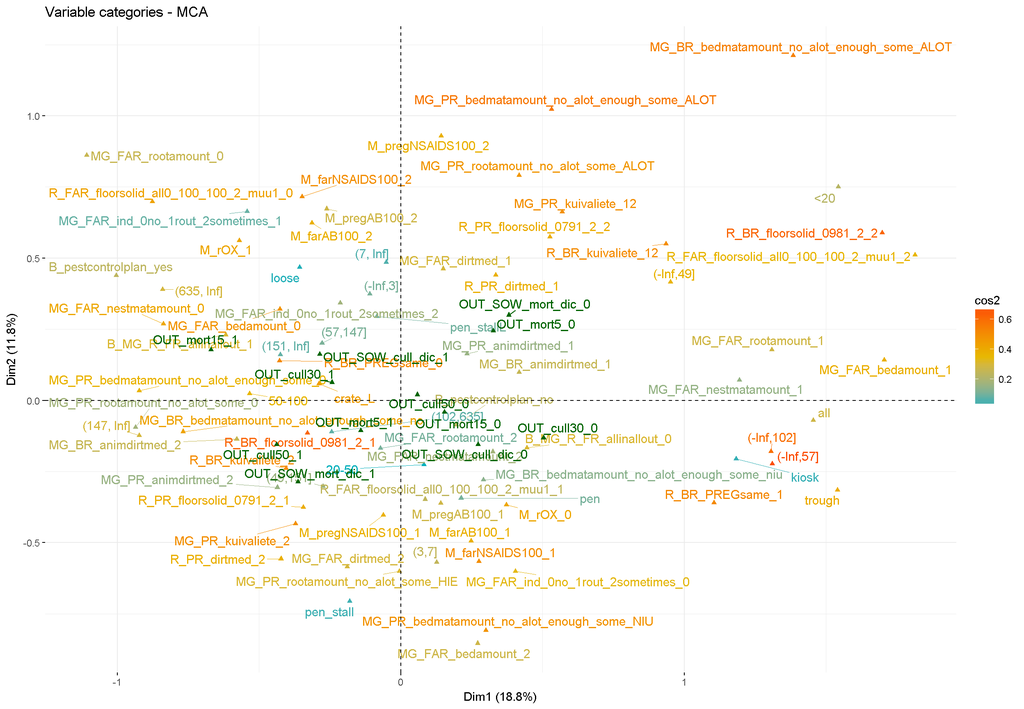

```r
# Color by cos2 values: quality on the factor map
fviz_mca_var(res_mca, col.var = "cos2",
             gradient.cols = c("#00AFBB", "#E7B800", "#FC4E07"),
             repel = TRUE, # Avoid text overlapping
             ggtheme = theme_minimal())
```

Similarly as with the contributions, it is also possible to create a bar plot of variable cos2 importance.

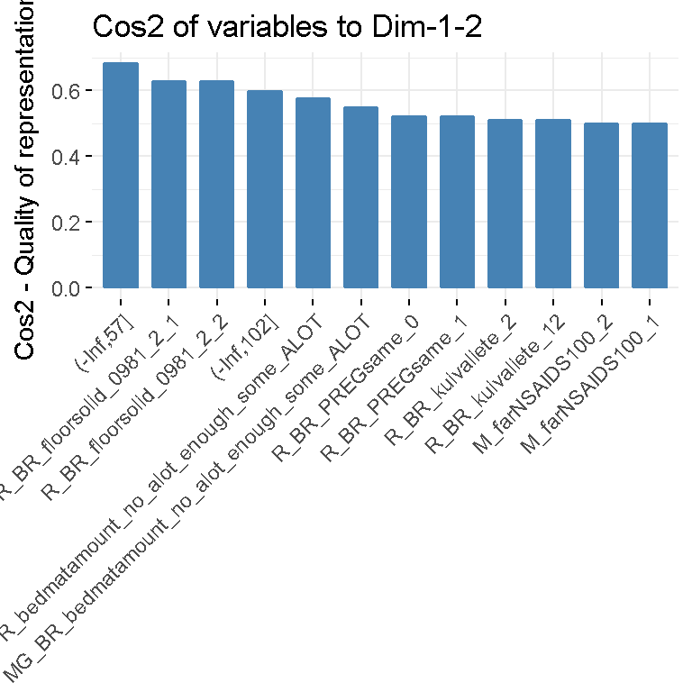

```r
# Cos2 of variable categories on Dim.1 and Dim.2
fviz_cos2(res_mca, n=10,choice = "var", axes = 1:2,top=12)
```